# Contribution Species Sorting and Evolution

Julius Hoffmann

2024-01-24

## Load packages

```r
library(tidyverse)
library(ggh4x)
library(lme4)
library(emmeans)
library(blmeco)
library(lmerTest)
library(flextable)
```

```r
set_flextable_defaults(
  font.size = 10, theme_fun = theme_vanilla,
  padding = 6,
  font.family = "Arial")
```

## Load data

Species frequencies from 16s rRNA sequencing, initial trait data and trait data on clones isolated during the community (mis-)match experiment are loaded.

```r
Species_counts <- read.csv("../Data/sequencing_counts and metadata.csv", sep = ",")
EVO_Trait <- read_tsv("../Data/Evolved Initial Traits AMiGA.txt")
ANC_Trait <- read_tsv("../Data/Ancestral Initial Traits AMiGA.txt")
Traits_obs <- read.csv("../derived data/Clone_OD_96h.txt")
```

## Data clean-up

Before working with the data it needs to be brought into the right shape.

1. Only the necessary data is selected.

```r
Traits_obs <- Traits_obs[,2:8]

##select relevant information from the 16s-rRNA counts data
Species_counts <- Species_counts[,c(2,3,4,5,8,9,10,11)]

##change replicate names to numeric ones to match the identifiers used in the trait data
old_rep <- c("A","C","E")
new_rep <- c("1","3","5")
Species_counts[,"replicate"]  <- new_rep[match(Species_counts[,"replicate"], old_rep, nomatch = 0)] #removes other replicates
```

2. Variable names and values:

All information is re-named to be cohesive across all types of data.

```r
##to match the column names of EVO and ANC Trait to the ones used in 16s-rRNA counts
colnames(EVO_Trait) <-c("strainID","prey_history", "growth", "pred_treatment", "defence") #, "genus", "species"
colnames(ANC_Trait) <-c("strainID","prey_history", "growth", "pred_treatment", "defence")#, "genus", "species"
##to match the columns in the observed trait data to the initial trait data and 16s-rRNA counts
colnames(Traits_obs) <- c("growth","growth_with_ciliates","prey_history", "predator_history","replicate","time_days",  "defence")

##to match predator and bacteria identifier in the observed trait data to the initial trait data and 16s-rRNA counts
Traits_obs[,"prey_history"] <- replace(Traits_obs[,"prey_history"], Traits_obs[,"prey_history"] == "Ancestral Bacteria", c("ANC") )
Traits_obs[,"prey_history"] <- replace(Traits_obs[,"prey_history"], Traits_obs[,"prey_history"] == "Evolved Bacteria", c("EVO") )
Traits_obs[,"predator_history"] <- replace(Traits_obs[,"predator_history"], Traits_obs[,"predator_history"] == "Ancestral Ciliates", c("ANC") )
Traits_obs[,"predator_history"] <- replace(Traits_obs[,"predator_history"], Traits_obs[,"predator_history"] == "Evolved Ciliates", c("EVO") )
Traits_obs[,"replicate"]<-as.character(Traits_obs[,"replicate"])
##create indices that will later help to align predicted trait distributions with measured trait distributions
Traits_obs <- Traits_obs %>%
  group_by(replicate, prey_history, predator_history, time_days) %>%
  mutate(indices = c(1:24)) %>%
  ungroup()
```

3. StrainID and Species names are extracted from the 16s rRNA sequencing data

```r
StrainID <- Species_counts[1:24,1] #StrainID
SpeciesNames <- paste(Species_counts[1:24,2],Species_counts[1:24,3], sep = " ") #SpeciesNames
```

## Start Analysis

1. Calculate relative species frequencies from the 16s-rRNA counts
2. Initial trait data is joined with species frequencies in one data frame

```r
freq_counts <- Species_counts %>%
  group_by(replicate, prey_history, predator_history, time_days) %>%
  mutate(freq = count/sum(count))# %>%  #This is the crucial info for Bootstrap Traits
#join initial ancestral and evolved traits
init_traits <- rbind(ANC_Trait, EVO_Trait)

#join initial ancestral and evolved traits with species frequencies
Prediciton <- right_join(freq_counts, init_traits)
```

## Prediction vs Observation

Relative frequencies of each species in each replicate on the sampling days 8, 28 and 60 were computed. These frequencies are now used as probabilities to sample from the initial trait pairs in samples of size 24. This is done 100x for each combination of microcosm, prey_history, predator_history and time_days with separate traits for ancestral and evolved prey. The resulting data frame is then combined with a data frame containing the measured samples, so that the 24 values of prediction per ‘bootstrapped’ sample are aligned with the 24 measured values. Consequently, the median of the predicted and observed samples are calculated and for each the ratio between observation and prediction is calculated (termed “deviation ratio”).

```r
for( i in 1:100){

  Pred_Trait <- Prediciton %>%
    filter(time_days %in% c(8,28,60) & predator_history %in% c("ANC","EVO")) %>% #filter data on days 8, 28 and 60
    group_by(replicate, prey_history, predator_history, time_days) %>% #group according to samples
    reframe(bs_df = sample(x= defence, size=24, replace=TRUE, prob=freq),#create the sample according to initial traits and species frequencies (also called "prediction")
              indices = c(1:24)) %>% #add indices 1 to 24
    ungroup() %>%
    mutate(bs_growth = init_traits$growth[match(.$bs_df,init_traits$defence)])#match sampled defence values with their corresponding carrying capacity values


  Joined_traits <- right_join(Pred_Trait, Traits_obs)  #combine "predictions" and measurements
  Joined_traits[,c("bs_df","defence" )] <-  replace(Joined_traits[,c("bs_df","defence" )], Joined_traits[,c("bs_df","defence" )] > 0, c(NA)) #replace defence values > 0 with NA, we consider these values biologically implausible.

  Joined_traits <- Joined_traits %>%                                                     #calculate median trait values for predicted and observed traits
    group_by(replicate, prey_history, predator_history, time_days) %>%
    reframe( predicted.median.def = median(bs_df, na.rm = TRUE),
             predicted.median.growth = median(bs_growth, na.rm = TRUE),
             observed.median.def = median(defence, na.rm = TRUE),
             observed.median.growth = median(growth, na.rm = TRUE),
             ) %>% #calculate ratio between predicted and oserved traits
    mutate(ratio_predicted_observed_df = observed.median.def/predicted.median.def,
           ratio_predicted_observed_growth = observed.median.growth/predicted.median.growth)




  if(i<2)
  {

    simulated_median <- rep( i, dim(Joined_traits)[1])
    prediction.vs.observed <- cbind(Joined_traits, simulated_median)

  } else {
    simulated_median <- rep( i, dim(Joined_traits)[1])
    joined_traits <- cbind(Joined_traits, simulated_median )

    prediction.vs.observed  <- rbind(prediction.vs.observed,joined_traits)
  }

}
```

Now the data is tidied up by re-naming variable values and setting the correct variable classes

```r
prediction.vs.observed <- prediction.vs.observed %>%
  mutate(prey_history = str_replace_all(prey_history, c("ANC" = "Anc_prey", "EVO" = "Evo_prey")),
         predator_history = str_replace_all(predator_history, c("ANC" = "Anc_predator", "EVO" = "Evo_predator")))

prediction.vs.observed$replicate <- as.factor(prediction.vs.observed$replicate)
prediction.vs.observed$prey_history <- as.factor(prediction.vs.observed$prey_history)
prediction.vs.observed$predator_history <- as.factor(prediction.vs.observed$predator_history)
```

Deviation ratios are log-transform to make them easier to interpret (i.e. deviations in both directions are equally scaled)

```r
prediction.vs.observed  <- prediction.vs.observed %>%
  mutate(ratio_predicted_observed_df = log(ratio_predicted_observed_df),
          ratio_predicted_observed_growth = log(ratio_predicted_observed_growth))
```

```r
##
prediction.observed.median <- prediction.vs.observed %>%
  group_by(replicate,prey_history,predator_history,time_days) %>%
  reframe(median_ratio_df = mean(ratio_predicted_observed_df),
  median_ratio_growth = mean(ratio_predicted_observed_growth))
```

## Assess evolutionary contributions over time with a linear model

1. Distinguishable replicate names and correct variable classes are set

```r
prediction.vs.observed$replicate <- as.factor(prediction.vs.observed$replicate)
prediction.vs.observed$prey_history <- as.factor(prediction.vs.observed$prey_history)
prediction.vs.observed$predator_history <- as.factor(prediction.vs.observed$predator_history)
prediction.vs.observed$time_days <- as.numeric(prediction.vs.observed$time_days)

prediction.vs.observed <- prediction.vs.observed %>%
  group_by(predator_history, prey_history, replicate ) %>%
  mutate(Replicate_unique = cur_group_id() ) %>%
  ungroup()

prediction.vs.observed$Replicate_unique <- as.factor(prediction.vs.observed$Replicate_unique)
```

2. A normal linear model is run for each trait to derive slopes + intercept for each microcosm.

Model for carrying capacity:

```r
ratio_model_growth <- lm(ratio_predicted_observed_growth ~ Replicate_unique/time_days -1 ,data = prediction.vs.observed)
```

Model for defence:

```r
ratio_model_df <- lm(ratio_predicted_observed_df ~ Replicate_unique/time_days -1 ,data = prediction.vs.observed)
```

3. Model output for both traits:

```r
tf_ratio_model_growth <- as_flextable(ratio_model_growth)
tf_ratio_model_growth
```

|  | Estimate | Standard Error | t value | Pr(>\|t\|) |  |
| --- | --- | --- | --- | --- | --- |
| Replicate_unique1 | 0.463 | 0.029 | 16.183 | 0.0000 | *** |
| Replicate_unique2 | -0.032 | 0.029 | -1.104 | 0.2697 |  |
| Replicate_unique3 | 0.331 | 0.029 | 11.558 | 0.0000 | *** |
| Replicate_unique4 | -0.389 | 0.029 | -13.590 | 0.0000 | *** |
| Replicate_unique5 | -0.380 | 0.029 | -13.270 | 0.0000 | *** |
| Replicate_unique6 | -0.022 | 0.029 | -0.771 | 0.4407 |  |
| Replicate_unique7 | 0.275 | 0.029 | 9.614 | 0.0000 | *** |
| Replicate_unique8 | -0.009 | 0.029 | -0.324 | 0.7462 |  |
| Replicate_unique9 | 0.292 | 0.029 | 10.209 | 0.0000 | *** |
| Replicate_unique10 | -0.255 | 0.029 | -8.910 | 0.0000 | *** |
| Replicate_unique11 | -1.134 | 0.029 | -39.628 | 0.0000 | *** |
| Replicate_unique12 | -0.516 | 0.029 | -18.023 | 0.0000 | *** |
| Replicate_unique1:time_days | -0.003 | 0.001 | -3.379 | 0.0007 | *** |
| Replicate_unique2:time_days | -0.001 | 0.001 | -1.303 | 0.1928 |  |
| Replicate_unique3:time_days | -0.006 | 0.001 | -8.207 | 0.0000 | *** |
| Replicate_unique4:time_days | 0.010 | 0.001 | 13.423 | 0.0000 | *** |
| Replicate_unique5:time_days | 0.006 | 0.001 | 8.199 | 0.0000 | *** |
| Replicate_unique6:time_days | -0.017 | 0.001 | -22.826 | 0.0000 | *** |
| Replicate_unique7:time_days | -0.006 | 0.001 | -8.442 | 0.0000 | *** |
| Replicate_unique8:time_days | -0.007 | 0.001 | -9.074 | 0.0000 | *** |
| Replicate_unique9:time_days | -0.008 | 0.001 | -10.892 | 0.0000 | *** |
| Replicate_unique10:time_days | 0.004 | 0.001 | 4.963 | 0.0000 | *** |
| Replicate_unique11:time_days | 0.017 | 0.001 | 22.954 | 0.0000 | *** |
| Replicate_unique12:time_days | 0.012 | 0.001 | 15.677 | 0.0000 | *** |

Signif. codes: 0 <= '***' < 0.001 < '**' < 0.01 < '*' < 0.05  
Residual standard error: 0.2757 on 3576 degrees of freedom  
Multiple R-squared: 0.6163, Adjusted R-squared: 0.6137  
F-statistic: 239.3 on 3576 and 24 DF, p-value: 0.0000

```r
tf_ratio_model_df <- as_flextable(ratio_model_df)
tf_ratio_model_df
```

[output not shown]

Signif. codes: 0 <= '***' < 0.001 < '**' < 0.01 < '*' < 0.05  
Residual standard error: 0.3989 on 3576 degrees of freedom  
Multiple R-squared: 0.9498, Adjusted R-squared: 0.9494  
F-statistic: 2817 on 3576 and 24 DF, p-value: 0.0000

4. Check of model assumptions:

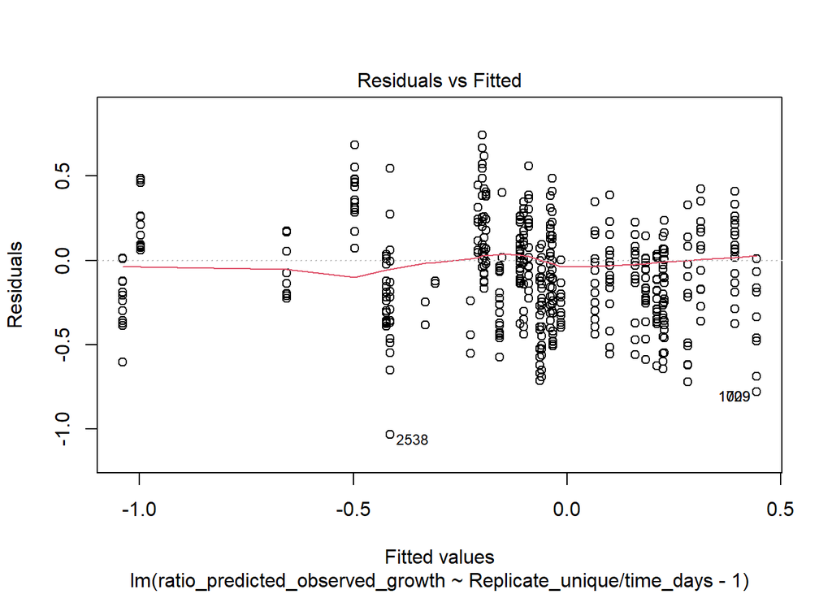

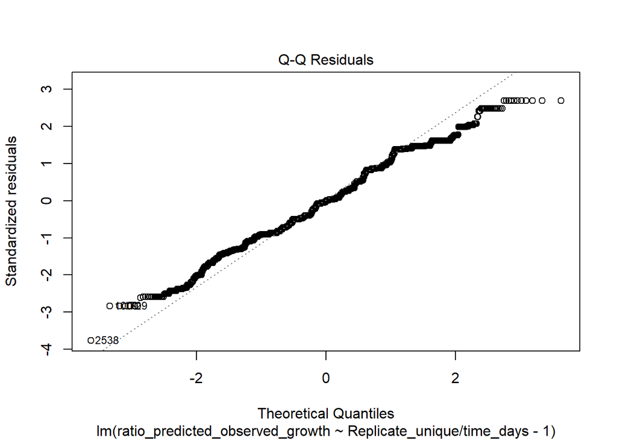

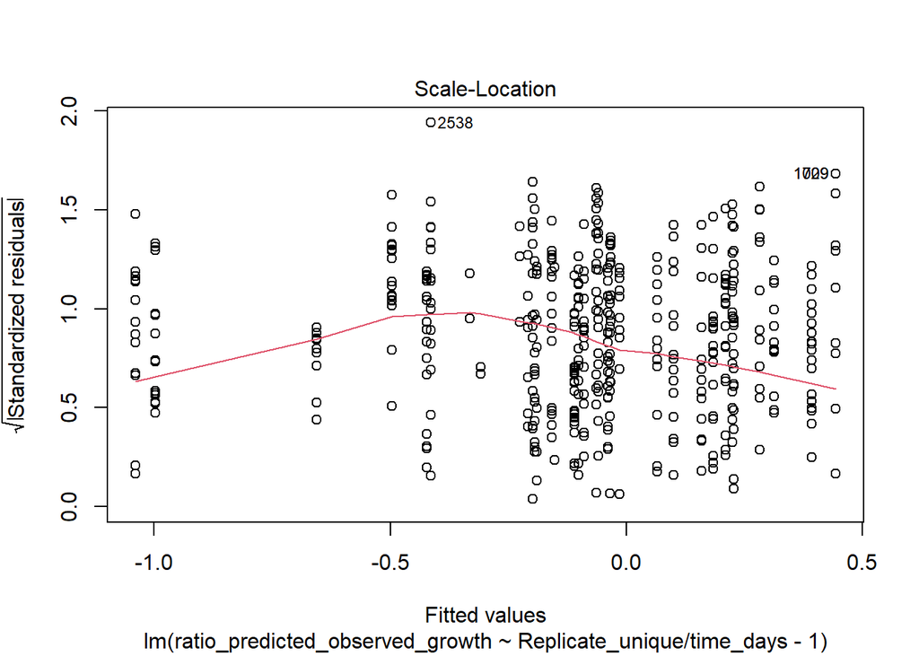

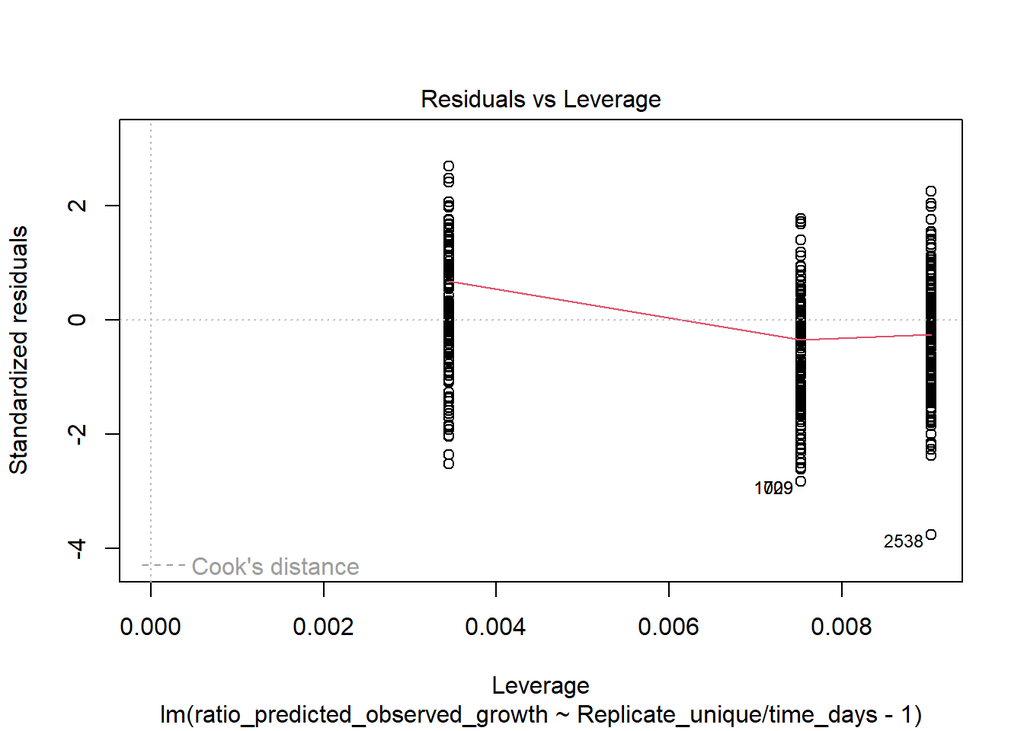

```r
#assumptions carrying capacity
plot(ratio_model_growth)
```

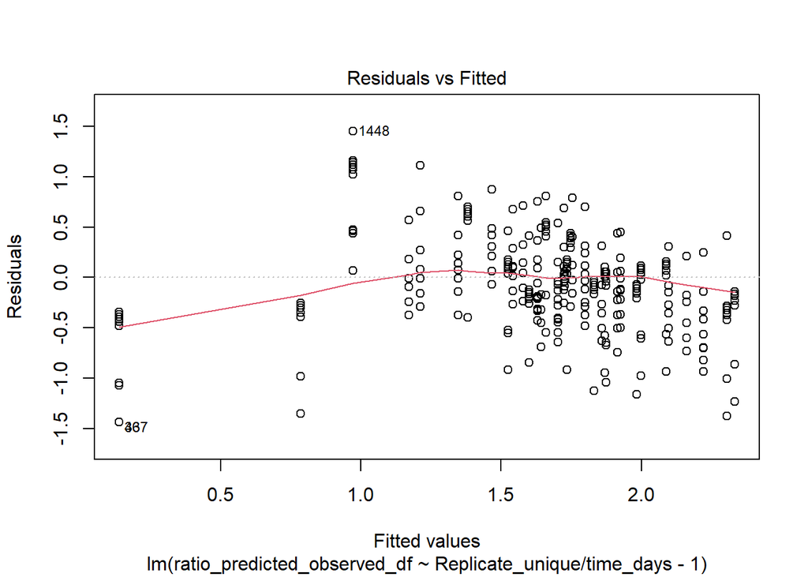

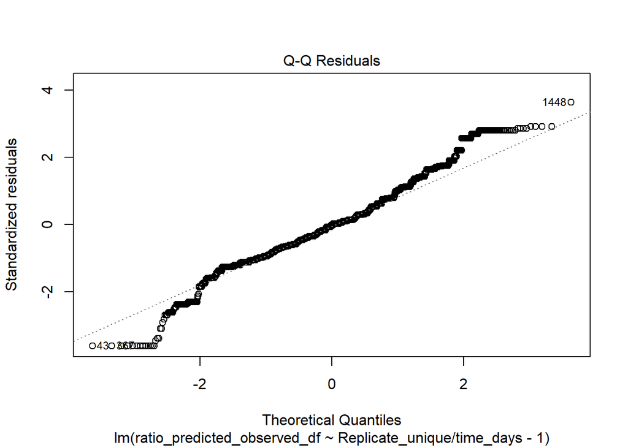

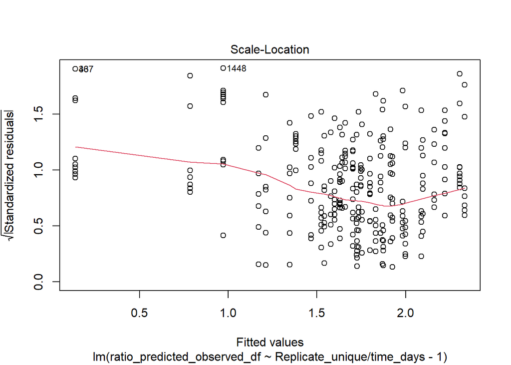

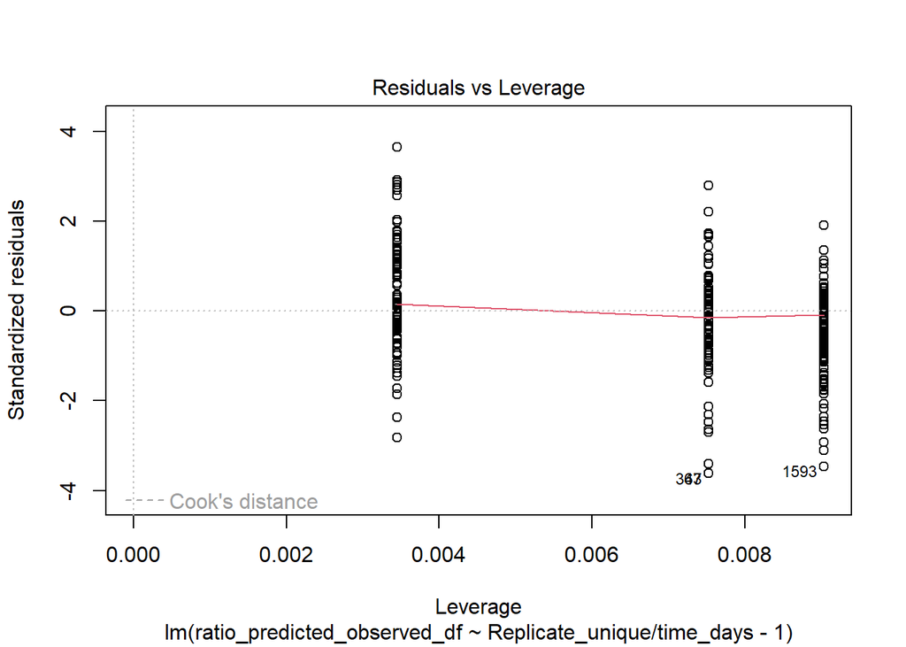

```r
#assumptions defence
plot(ratio_model_df)
```

```r
type <- c(rep("intercept",12),rep("slope",12))

groups <- prediction.vs.observed %>%
  group_by(predator_history, prey_history, replicate, Replicate_unique ) %>%
  group_keys()

#for growth capacity
result_growth <- as.data.frame(coef(summary(ratio_model_growth)))
regressions_growth <- cbind(type, result_growth)
regression_results_growth <- cbind(groups, regressions_growth)
row.names(regression_results_growth)<- NULL

#mean estimates + standard deviation
mean_estimates_growth <- regression_results_growth %>%
  group_by(type) %>%
  reframe(mean_estimate= mean(Estimate),
          sd_estimate= sd(Estimate))

#for defence
result_df <- as.data.frame(coef(summary(ratio_model_df)))
regressions_df <- cbind(type, result_df)
regression_results_df <- cbind(groups, regressions_df)
row.names(regression_results_df)<- NULL

#mean estimates + standard deviation
mean_estimates_df <- regression_results_df %>%
  group_by(type) %>%
  reframe(mean_estimate= mean(Estimate),
          sd_estimate= sd(Estimate))
```

## Visualise analysis (Fig. 5)

1. Prepare lables

```r
prey.labs <- c("ancestral prey", "evolved prey")
names(prey.labs) <- c("Anc_prey", "Evo_prey")

predator.labs <-  c("ancestral ciliates", "evolved ciliates")
names(predator.labs) <- c("Anc_predator", "Evo_predator")
```

2. Plot deviation ratios for carrying capacity:

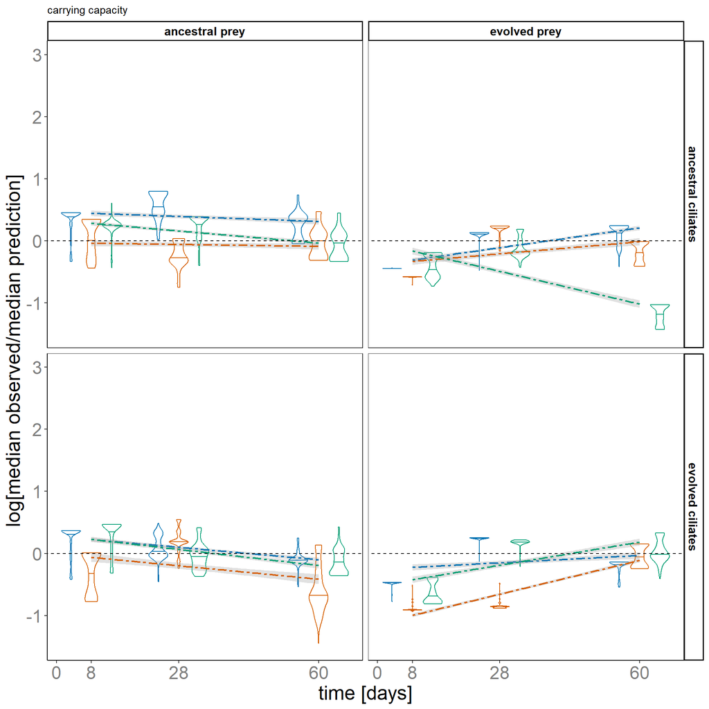

3. Plot deviation ratios for defence:

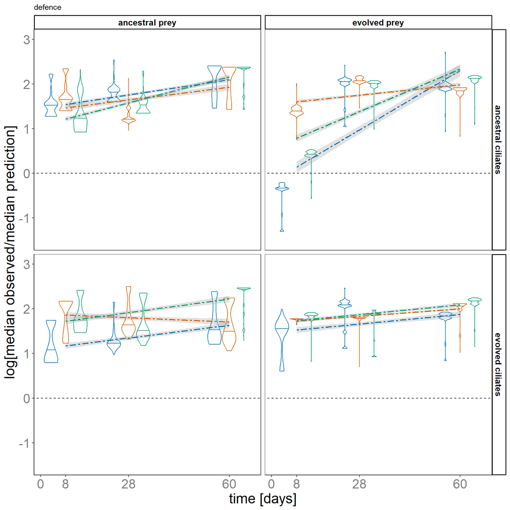

Plotting predicted vs observed trait distributions

```r
backgrounds <- list(NULL,element_blank())
texts<- list(NULL,element_blank())
disabled_strip <- strip_nested(
  background_x = backgrounds,
  text_x = texts,
  by_layer_x = TRUE)
```

For carrying capacity:

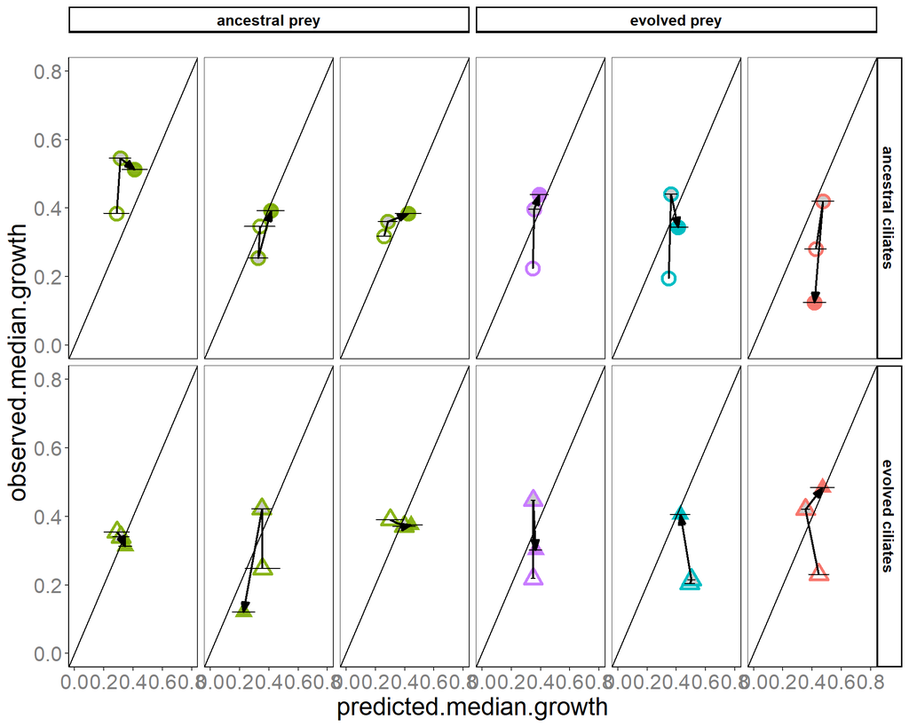

For defence:

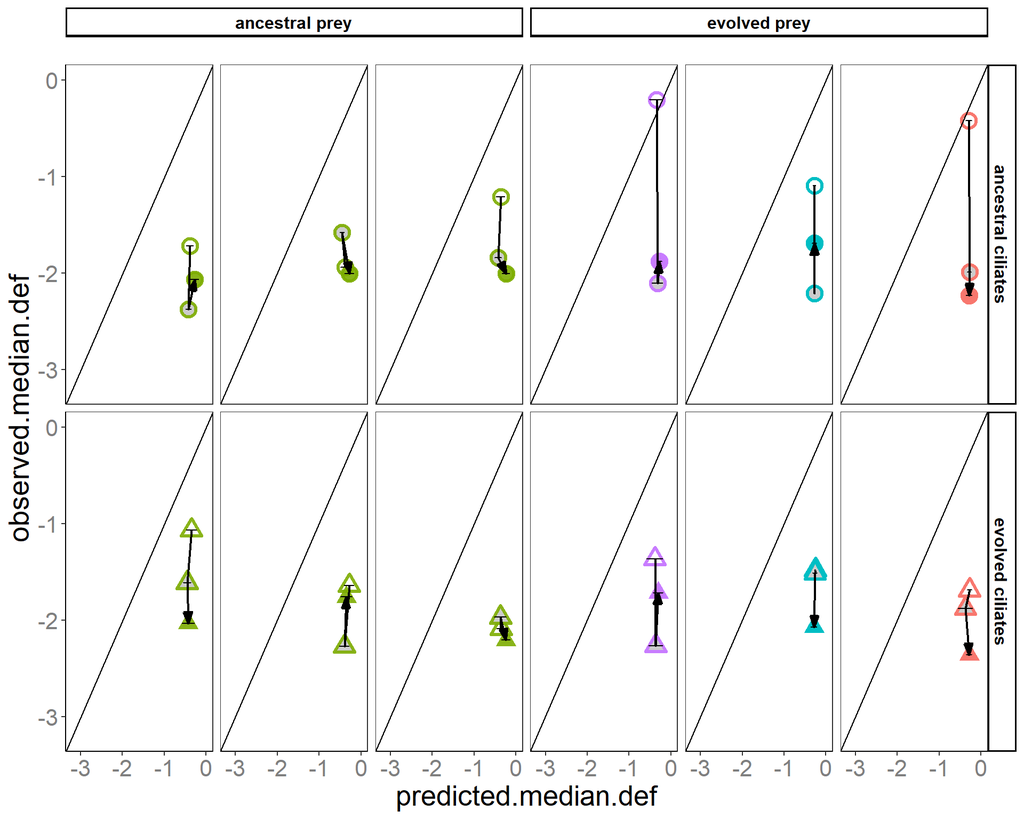